# SYTO9 and PI permeability (signal) as a function of oxidative damage

Bin He, originally by Hanxi Tang

2023-12-18, modified 2024-09-26, updated 2026-06-18

```r
require(flowCore)
require(flowClust)
require(openCyto)
require(tidyverse)
require(ggcyto)
require(cowplot)
```

```r
require(here)
i_am("analysis/14.01-SYTO9-PI-signal-in-oxidative-stressed-cells.Rmd")
```

# Goal

We observed an intermediate high-green high-red population most prominent in the 100 mM treated cells. This is different from what’s shown in the FungaLight manual. We hypothesize that the high-green high-red popuplation are damaged cells that are more permeable to SYTO9 but not yet permeable to PI.

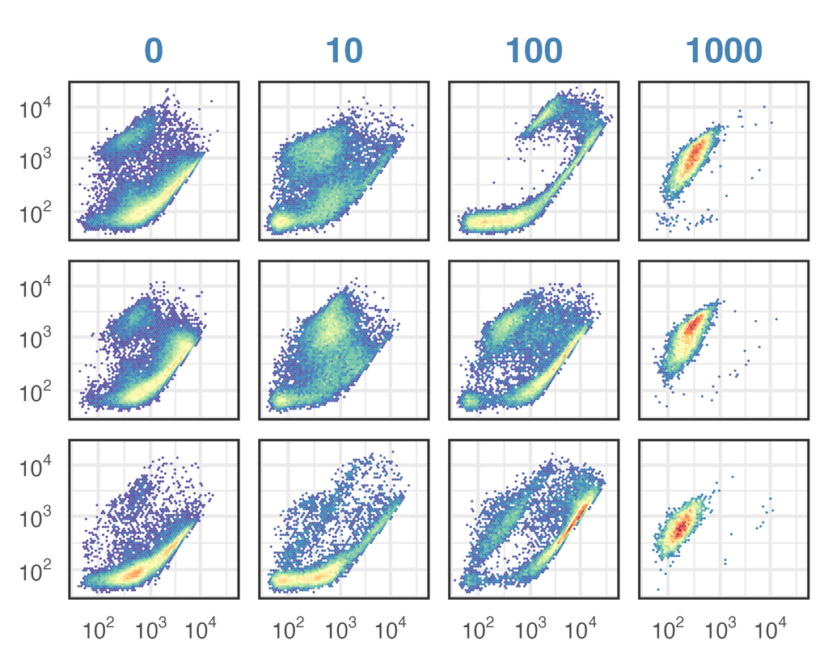

**Note the high green high red population in the 100 mM H2O2 treated *C. glabrata* cells**

**Our first goal** is to test this hypothesis by quantifying SYTO9 and PI staining signals in samples treated with increasing concentrations of hydrogen peroxide. To distinguish the signals in the red channel between SYTO9 and PI, we apply the two dyes separately.

**Our second goal** is to establish each dye’s staining pattern in mock-treated cells and optimize dye concentration.

# Data importing

> original FCS files are stored in RDSS/user/hanxi-tang/flow cytometry. FCS files are copied to the current directory

```r
# use relative path to make it easier for collaboration
data.path = here("input", "20231120 SYTO9 PI dilutions")
dat0 <- read.flowSet(path = data.path, transformation = FALSE,
                       # the original values are already linearized.
                       emptyValue = FALSE,  alter.names = TRUE,
                       # change parameter names to R format
                       column.pattern = ".H|FSC|SSC"
                       # only load the height variables for the fluorescent parameters
)
```

Simplify the sample names

```r
oriNames <- sampleNames(dat0)
tmp <- str_split(oriNames, pattern = "[ _]+", simplify = TRUE)[,c(1, 5, 6, 7)]
colnames(tmp) <- c("Date", "Treatment", "Dilution", "Dye")
sample <- data.frame(tmp) %>%
  mutate(
    Date = mdy(Date),
    Dye = ifelse(Dye == "p.fcs", "PI", "SYTO9"),
    Dilution = as.numeric(gsub(".fcs", "", Dilution)),
    Treatment = factor(Treatment, levels = c(0, 10, 100, 1000))
  )
rownames(sample) <- oriNames
dat <- dat0
pData(dat) = sample
write_tsv(sample, file =
            here("input", "20231222-SYTO9-PI-permeability-sample-info.tsv"))
```

Set up factor levels

```r
dilution.levels = paste(c(250, 500, 1000, 2000), "x", sep = "")
names(dilution.levels) = c(250, 500, 1000, 2000)
treat.levels = paste(c(0, 10, 100), "mM", sep = " ") |> c("1M")
names(treat.levels) = c(0, 10, 100, 1000)
```

# Data preprocessing

## Gating for singlets

> The following gaphing steps are used to gate singlets by FSC and SSC values. Only singlets are included in analysis.

> Gate for outlier

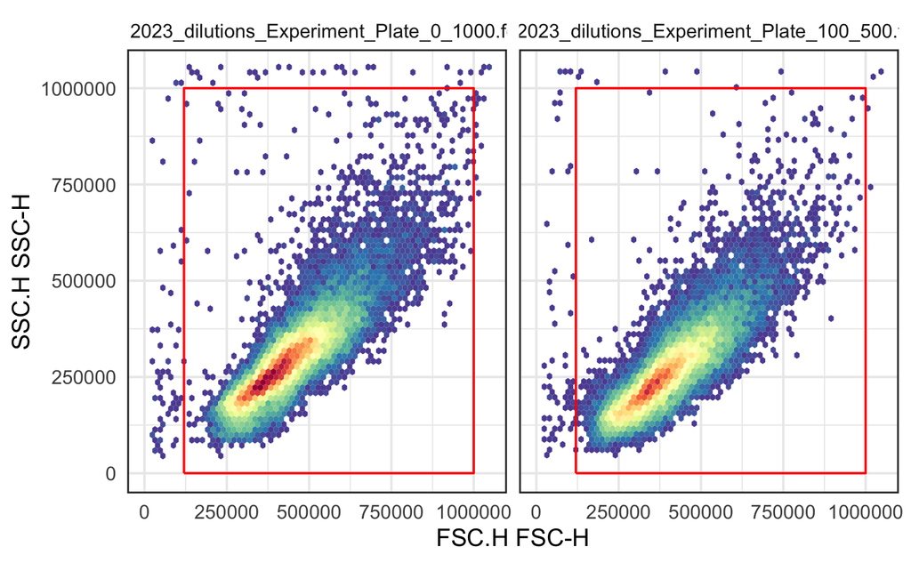

```r
outlier.gate <- rectangleGate(filterId = "-outlier", "FSC.H" = c(1.2e5, 1e6), "SSC.H" = c(1e2, 1e6))
ggcyto(dat[c(2,24)], aes(x = FSC.H, y = SSC.H), subset = "root") +
  geom_hex(bins = 64) + geom_gate(outlier.gate) + facet_wrap(~name, ncol = 2) +
  ggcyto_par_set(limits = "instrument")
```

Add gate to GS

```r
gs <- GatingSet(dat) # create a GatingSet
gs_pop_add(gs, outlier.gate, parent = "root")
```

```
[1] 2
```

```r
recompute(gs)
```

> Gate for singlets

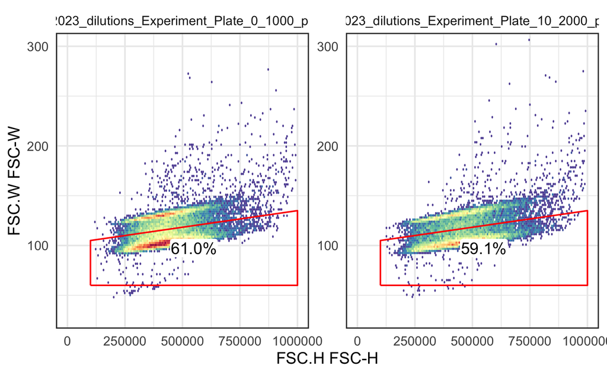

```r
scPars <- ggcyto_par_set(limits = list(x = c(0,1e6), y = c(30,300)))
ex <- Subset(dat[c(1,11)], outlier.gate)
polygon <- matrix(c(1e5, 1e5, 1e6, 1e6,
                    60, 105, 135,60), ncol = 2)
colnames(polygon) <- c("FSC.H", "FSC.W")
singlet.gate <- polygonGate(filterId = "singlet", .gate = polygon)
ggcyto(ex, aes(x = FSC.H, y = FSC.W)) +
  geom_hex(bins = 128) +
  geom_gate(singlet.gate) + geom_stats() +
  scPars + panel_border(color = "gray20")
```

Add this gate to the gatingSet

```r
gs_pop_add(gs, singlet.gate, parent = "-outlier", name = "singlet")
```

```
[1] 3
```

```r
recompute(gs)
```

## Gate for PI-positive cells

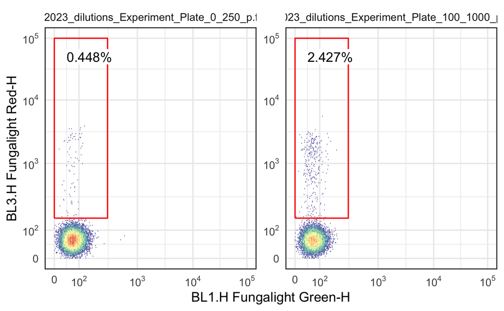

```r
scPars <- ggcyto_par_set(limits = list(x = c(0,1e5), y = c(0,1e5)))
ex <- Subset(dat[c(5, 17)], singlet.gate)
polygon <- matrix(c(0, 10^2.5, 10^2.5, 0,
                    10^2.2, 10^2.2, 10^5, 10^5), ncol = 2)
colnames(polygon) <- c("BL1.H", "BL3.H")
PI.gate <- polygonGate(filterId = "PI-positive", .gate = polygon)
ggcyto(ex, aes(x = BL1.H, y = BL3.H)) + geom_hex(bins = 128) + geom_gate(PI.gate) + geom_stats() + scPars + scale_x_logicle() + scale_y_logicle()
```

Add this gate to the gatingSet

```r
gs_pop_add(gs, PI.gate, parent = "singlet", name = "PI-positive")
```

```
[1] 4
```

```r
recompute(gs)
```

## Gate for SYTO9 high-green and high-red population

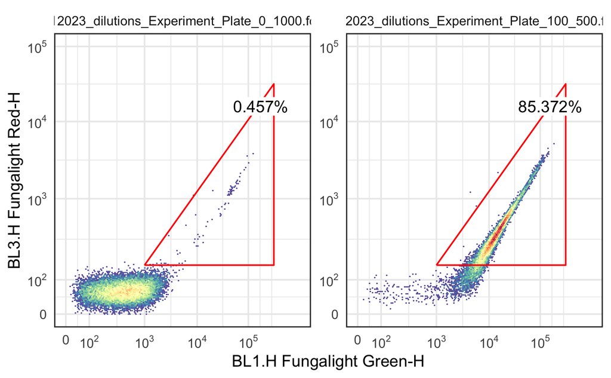

```r
scPars <- ggcyto_par_set(limits = list(x = c(0,1e6), y = c(0,1e5)))
ex <- Subset(dat[c(2, 24)], singlet.gate)
polygon <- matrix(c(10^3, 10^5.5, 10^5.5,   # BL1.H green
                    10^2.2, 10^2.2, 10^4.5),# BL3.H red
                  ncol = 2)
#polygon <- matrix(c(1e2, 1e6, 1e6, 1e2,
#                    10^2, 10^2, 1e6, 1e6), ncol = 2)
colnames(polygon) <- c("BL1.H", "BL3.H")
SYTO9.gate <- polygonGate(filterId = "Intermediate", .gate = polygon)
ggcyto(ex, aes(x = BL1.H, y = BL3.H)) +
  geom_hex(bins = 128) +
  geom_gate(SYTO9.gate) + geom_stats() + scPars +
  scale_x_logicle() + scale_y_logicle()
```

Add this gate to the gatingSet

```r
gs_pop_add(gs, SYTO9.gate, parent = "singlet", name = "Intermediate")
```

```
[1] 5
```

```r
recompute(gs)
```

## Gate for unstained cells

For SYTO9, which in theory stains all cells, this gate identifies poorly or unstained cells; for PI, this identifies live cells not permeable to PI.

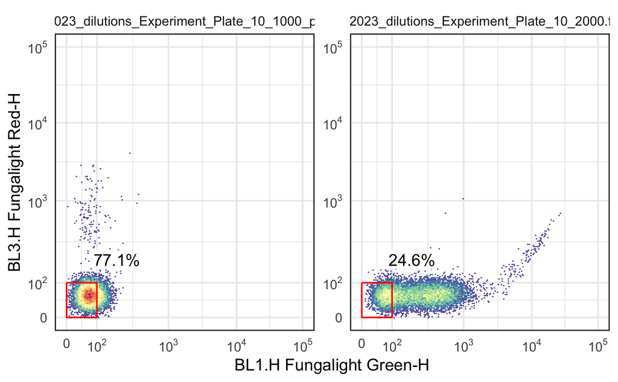

```r
scPars <- ggcyto_par_set(limits = list(x = c(0,1e5), y = c(0,1e5)))
ex <- Subset(dat[c(9,12)], singlet.gate)
polygon <- matrix(c(0, 10^2, 10^2, 0,     # BL1.H, green
                    10^2, 10^2, 0, 0),# BL3.H, red
                  ncol = 2)
colnames(polygon) <- c("BL1.H", "BL3.H")
unstained.gate <- polygonGate(filterId = "unstained", .gate = polygon)
ggcyto(ex, aes(x = BL1.H, y = BL3.H)) +
  geom_hex(bins = 128) +
  geom_gate(unstained.gate) + geom_stats(adjust = c(2, 2)) + scPars +
  scale_x_logicle() + scale_y_logicle()
```

Add this gate to the gatingSet

```r
gs_pop_add(gs, unstained.gate, parent = "singlet", name = "unstained")
```

```
[1] 6
```

```r
recompute(gs)
```

## Extract population statistics

Export the counts and MFI separately

```r
# we are only interested in the populations after singlet gating
nodes <- c("singlet", "PI-positive", "Intermediate", "unstained")
# get the event count
gated_cnt <- gs_pop_get_stats(gs, nodes, type = "count")
# get the MFI for each parameter in each population of interest
gated_mfi <- gs_pop_get_stats(gs, nodes, type = pop.MFI) %>%
  select(sample, pop, starts_with("FungaLight"))
```

combine the two datasets

```r
gated_stats <- full_join(gated_cnt, gated_mfi, by = c("sample", "pop")) %>%
  right_join(pData(gs), by = c("sample" = "name")) %>%
  relocate(Date, Treatment, Dye, Dilution, .after = sample) %>%
  relocate(sample, .after = last_col())
write_tsv(gated_stats, file = here("output","20260611-Cg-SYTO9-gated-stats.tsv"))
```

# Analysis 1: SYTO 9 signal over peroxide dose

SYTO 9 is used in this combo dye to stain “all cells”, live or dead. However, previous studies and our observation led us to hypothesize that SYTO 9 staining intensity is higher in samples receiving a stronger dose of oxidative stress. This combined with SYTO 9 signal bleeding into the red channel could explain the “intermediate population” we observed. Here, we test this hypothesis by comparing SYTO 9 single stain patterns in samples treated with different levels of peroxide stress.

## Overview of staining pattern with one replicate

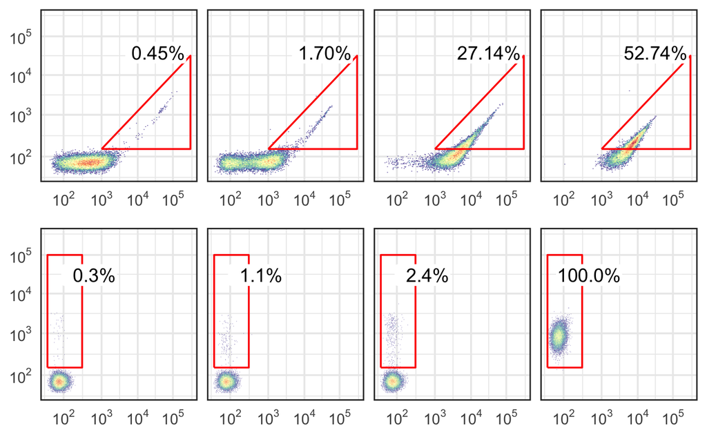

```r
scPars <- ggcyto_par_set(limits = list(x = c(0,10^5.5), y = c(0,10^5.5)))

# set some thematic elements
p.common <- list(
  scale_x_logicle(breaks = 10^c(2,3,4,5)),
  scale_y_logicle(breaks = 10^c(2,3,4,5)),
  labs(title = NULL, x = NULL, y = NULL)
)
# PI positive
select <- with(pData(gs),
               Date == "2023-11-20" &  Dilution == "1000" & Dye == "PI")
p1 <- ggcyto(gs[select], subset = "singlet",
            aes(x = BL1.H, y = BL3.H)) +
  geom_hex(bins = 128) +
  geom_gate(PI.gate) +
  geom_stats(digits = 1, adjust = c(1.5, 0.3)) +
  facet_wrap(~Treatment, nrow = 1) +
  p.common +
  theme(strip.text = element_blank()) + scPars

# SYTO9 intermediate
select <- with(pData(gs),
               Date == "2023-11-20" &  Dilution == "1000" & Dye == "SYTO9")
p2 <- ggcyto(gs[select], subset = "singlet",
            aes(x = BL1.H, y = BL3.H)) +
  geom_hex(bins = 128) +
  geom_gate(SYTO9.gate) +
  geom_stats(digits = 2, adjust = c(0.1, 1.2)) +
  facet_wrap(~Treatment, nrow = 1) +
  p.common +
  theme(strip.text = element_blank()) + scPars
plot_grid(as.ggplot(p2), as.ggplot(p1), nrow = 2, align = "h")
```

save the plot

```r
ggsave(here("output", "20250105-fig3a-PI-pos-intermediate-pop.png"),
       width = 6, height = 3.5)
```

## Stats, all replicates

Here we will be presenting the percentages of the PI-positive and Intermediate populations from all three replicates.

Plot the percentages

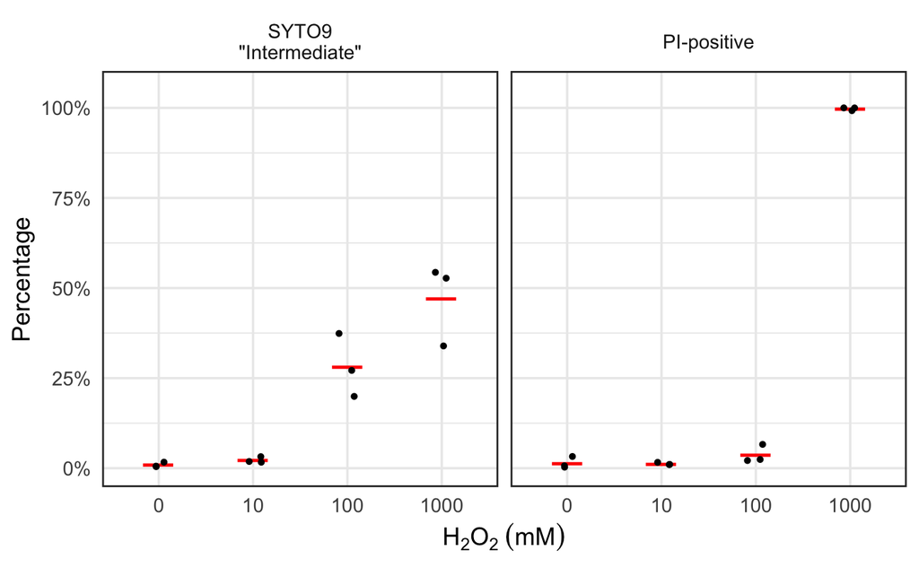

```r
# prepare data
tmp <- gated_stats %>%
  dplyr::filter(Dilution == "1000") %>%
  group_by(Date, Treatment, Dye) %>%
  mutate(perc = count / count[pop == "singlet"],
         .after = count) %>%
  # the following filtering function retains only the relevant subpopulation
  # count > 2 remove rows with the mismatching population and dye, e.g.,
  # PI-positive and SYTO9
  dplyr::filter(pop %in% c("PI-positive", "Intermediate"), count > 2) %>%
  mutate(Treatment = fct_inorder(Treatment),
         Dye = factor(Dye, levels = c("SYTO9", "PI")))

p <- tmp %>%
  ggplot(aes(x = Treatment, y = perc)) +
  #geom_bar(stat = "summary", fun = "mean", fill = "gray60", width = 0.6) +
  stat_summary(fun = "mean", geom = "point", shape = 95, color = "red",
               size = 10) +
  geom_point(position = position_jitter(0.1), size = 1) +
  facet_wrap(~Dye,
             labeller = labeller(Dye = c("SYTO9" = 'SYTO9\n"Intermediate"',
                                         "PI" = "PI-positive"))) +
  scale_y_continuous(name = "Percentage", limits = c(0, 1.05),
                     labels = scales::percent) +
  xlab(bquote(H[2]*O[2]~(mM)))
p
```

save the plot

```r
ggsave("../output/20250106-fig3b-percent-PI-pos-SYTO9-inter-over-treat.png",
       width = 3.8, height = 2.8)
```

Statistical test (ANOVA) 1. For SYTO9

```r
lm <- lm(perc ~ Treatment, data = dplyr::filter(tmp, Dye == "SYTO9"))
summary(lm)
```

```
Call:
lm(formula = perc ~ Treatment, data = dplyr::filter(tmp, Dye ==
    "SYTO9"))

Residuals:
      Min        1Q    Median        3Q       Max
-0.130745 -0.006899 -0.003509  0.021506  0.092396

Coefficients:
              Estimate Std. Error t value Pr(>|t|)
(Intercept)   0.009016   0.041537   0.217  0.83360
Treatment10   0.013505   0.058742   0.230  0.82394
Treatment100  0.272581   0.058742   4.640  0.00167 **
Treatment1000 0.461063   0.058742   7.849 5.01e-05 ***
---
Signif. codes:  0 ‘***’ 0.001 ‘**’ 0.01 ‘*’ 0.05 ‘.’ 0.1 ‘ ’ 1

Residual standard error: 0.07194 on 8 degrees of freedom
Multiple R-squared:  0.9144,    Adjusted R-squared:  0.8823
F-statistic:  28.5 on 3 and 8 DF,  p-value: 0.0001273
```

2. For PI

```r
lm <- lm(perc ~ Treatment, data = dplyr::filter(tmp, Dye == "PI"))
summary(lm)
```

```
Call:
lm(formula = perc ~ Treatment, data = dplyr::filter(tmp, Dye ==
    "PI"))

Residuals:
      Min        1Q    Median        3Q       Max
-0.015884 -0.008262 -0.002000  0.002948  0.028914

Coefficients:
               Estimate Std. Error t value Pr(>|t|)
(Intercept)    0.014155   0.008752   1.617   0.1445
Treatment10   -0.001794   0.012378  -0.145   0.8883
Treatment100   0.023147   0.012378   1.870   0.0984 .
Treatment1000  0.983173   0.012378  79.431 7.04e-13 ***
---
Signif. codes:  0 ‘***’ 0.001 ‘**’ 0.01 ‘*’ 0.05 ‘.’ 0.1 ‘ ’ 1

Residual standard error: 0.01516 on 8 degrees of freedom
Multiple R-squared:  0.9991,    Adjusted R-squared:  0.9988
F-statistic:  3111 on 3 and 8 DF,  p-value: 1.324e-12
```

## MFI for all cells

MFI will be plotted for all events in order to reveal an overall increase in SYTO9 signal in contrast to PI

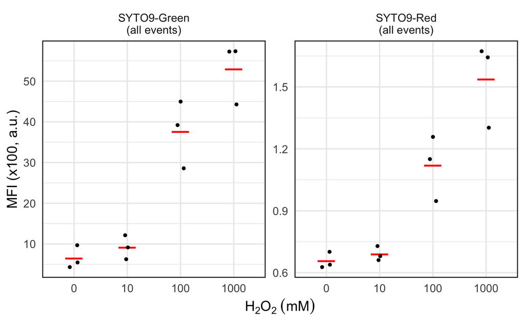

```r
# prepare data
tmp <- gated_stats %>%
  dplyr::filter(Dilution == "1000", pop == "singlet", Dye == "SYTO9") %>%
  rename(Green = "Fungalight Green-H", Red = "Fungalight Red-H") %>%
  mutate(Treatment = fct_inorder(Treatment)) %>%
  dplyr::select(Date, Treatment, Green, Red) %>%
  pivot_longer(Green:Red, names_to = "Channel", values_to = "MFI")

p <- tmp %>%
  ggplot(aes(x = Treatment, y = MFI)) +
  stat_summary(fun = "mean", geom = "point", color = "red",
               shape = 95, size = 10) +
  #stat_summary(aes(group = 1), fun = "mean", geom = "line", linetype = 2,
  #             linewidth = 0.7, color = "gray50") +
  geom_point(position = position_jitter(0.1), size = 1) +
  facet_wrap(~Channel, scale = "free_y",
             labeller = labeller(Channel =
                                   c("Green" = 'SYTO9-Green\n(all events)',
                                             "Red" = "SYTO9-Red\n(all events)"))) +
  xlab(bquote(H[2]*O[2]~(mM))) + #ylab("Fluorescence") +
  scale_y_continuous("MFI (x100, a.u.)",
                     labels = scales::label_number(scale = 1e-2))# +
  #theme(strip.text.x = element_text(margin = margin(0.4,0,0.4,0, "cm")))
p
```

save the plot

```r
ggsave(here("output", "20250106-fig3c-MFI-SYTO9-inter-over-treat.png"),
       width = 3.8, height = 2.8)
```

Statistical test (ANOVA) 1. For SYTO9, green channel

```r
lm <- lm(MFI ~ Treatment, data = dplyr::filter(tmp, Channel == "Green"))
summary(lm)
```

```
Call:
lm(formula = MFI ~ Treatment, data = dplyr::filter(tmp, Channel ==
    "Green"))

Residuals:
    Min      1Q  Median      3Q     Max
-899.00 -235.17   78.17  346.25  739.00

Coefficients:
              Estimate Std. Error t value Pr(>|t|)
(Intercept)      649.7      344.2   1.888 0.095787 .
Treatment10      268.0      486.8   0.551 0.596951
Treatment100    3110.3      486.8   6.390 0.000211 ***
Treatment1000   4644.3      486.8   9.541  1.2e-05 ***
---
Signif. codes:  0 ‘***’ 0.001 ‘**’ 0.01 ‘*’ 0.05 ‘.’ 0.1 ‘ ’ 1

Residual standard error: 596.1 on 8 degrees of freedom
Multiple R-squared:  0.9414,    Adjusted R-squared:  0.9194
F-statistic: 42.84 on 3 and 8 DF,  p-value: 2.833e-05
```

2. For SYTO9, red channel

```r
lm <- lm(MFI ~ Treatment, data = dplyr::filter(tmp, Channel == "Red"))
summary(lm)
```

```
Call:
lm(formula = MFI ~ Treatment, data = dplyr::filter(tmp, Channel ==
    "Red"))

Residuals:
    Min      1Q  Median      3Q     Max
-23.667  -2.750   1.000   5.833  14.000

Coefficients:
              Estimate Std. Error t value Pr(>|t|)
(Intercept)     65.667      7.619   8.618 2.55e-05 ***
Treatment10      3.333     10.775   0.309  0.76496
Treatment100    46.333     10.775   4.300  0.00262 **
Treatment1000   88.000     10.775   8.167 3.76e-05 ***
---
Signif. codes:  0 ‘***’ 0.001 ‘**’ 0.01 ‘*’ 0.05 ‘.’ 0.1 ‘ ’ 1

Residual standard error: 13.2 on 8 degrees of freedom
Multiple R-squared:  0.9175,    Adjusted R-squared:  0.8865
F-statistic: 29.65 on 3 and 8 DF,  p-value: 0.0001103
```

# Analysis 2: dye concentrations

The FungaLight manual recommends using the stock dye at 1000x dilution. We would like to determine how dye concentrations affect the staining pattern and whether the recommended 1000x dilution is optimal. Our criteria for optimality include:

1. Minimal “dead” and “damaged” populations in the mock-treated sample, i.e., not over-stained
2. Nearly all cells in the 1M H2O2 treated sample show up as dead, i.e., not under-stained, and
3. Consistent staining pattern across replicates.

## Illustration of the level of over- and under-staining with one replicate

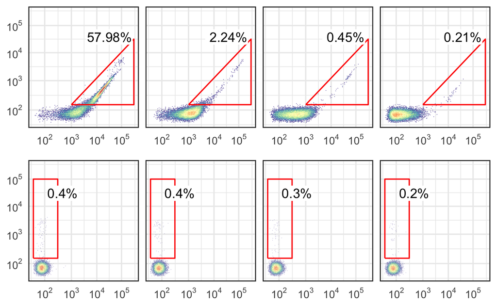

```r
scPars <- ggcyto_par_set(limits = list(x = c(0,10^5.5), y = c(0,10^5.5)))

# PI positive
select <- with(pData(gs),
               Date == "2023-11-20" &  Treatment == "0" & Dye == "PI")
p1 <- ggcyto(gs[select], subset = "singlet",
            aes(x = BL1.H, y = BL3.H)) +
  geom_hex(bins = 128) +
  geom_gate(PI.gate) +
  geom_stats(digits = 1, adjust = c(1.5, 0.3)) +
  facet_wrap(~factor(Dilution, levels = c("250", "500", "1000", "2000"),
                     labels = c("250x", "500x", "1000x", "2000x")), nrow = 1) +
  p.common +
  theme(strip.text = element_blank()) + scPars

# SYTO9 intermediate
select <- with(pData(gs),
               Date == "2023-11-20" &  Treatment == "0" & Dye == "SYTO9")
p2 <- ggcyto(gs[select], subset = "singlet",
            aes(x = BL1.H, y = BL3.H)) +
  geom_hex(bins = 128) +
  geom_gate(SYTO9.gate) +
  geom_stats(digits = 2, adjust = c(0.1, 1.2)) +
  facet_wrap(~factor(Dilution, levels = c("250", "500", "1000", "2000"),
                     labels = c("250x", "500x", "1000x", "2000x")), nrow = 1) +
  p.common +
  theme(strip.text = element_blank()) + scPars
plot_grid(as.ggplot(p2), as.ggplot(p1), nrow = 2, align = "h")
```

## Plot gated pop frequencies across treatments and dye dilutions

Prepare the summary stats

```r
tmp <- gated_stats %>%
  group_by(Date, Treatment, Dye, Dilution) %>%
  mutate(perc = count / count[pop == "singlet"],
         .after = count) %>%
  # the following filtering function removes the singlet gate and retains only the relevant subpopulation
  # count > 2 remove rows with the mismatching population and dye, e.g.,
  # PI-positive and SYTO9
  dplyr::filter(pop != "singlet", count > 2) %>%
  mutate(Treatment = fct_inorder(Treatment),
         Dilution = factor(Dilution, levels = c(250, 500, 1000, 2000),
                           labels = c("250x", "500x", "1000x", "2000x")),
         Dye = factor(Dye, levels = c("SYTO9", "PI")))
```

Designing the plot for SYTO 9

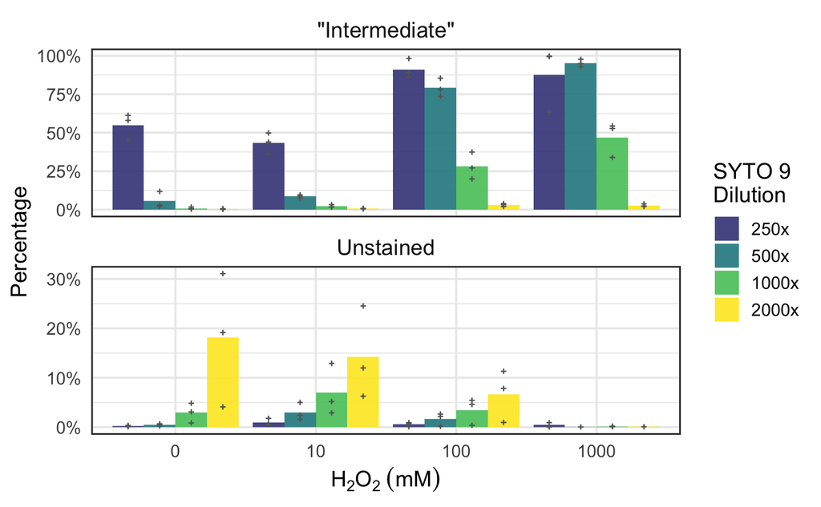

```r
pd = position_dodge(width = 0.9)
p <- tmp |>
  dplyr::filter(Dye == "SYTO9", pop %in% c("unstained", "Intermediate")) |>
  ggplot(aes(x = Treatment, y = perc, group = Dilution)) +
  geom_bar(aes(fill = Dilution), stat = "summary", fun = "mean",
           position = pd, alpha = 0.9) +
  #stat_summary(fun.data = "mean_sdl", fun.args = list(mult = 1),
  #             position = pd,
  #             geom = "errorbar", width = 0.2, color = "black") +
  geom_point(position = pd, color = "gray40", size = .5, shape = 3) +
  facet_wrap(~pop, nrow = 2, scales = "free_y",
             labeller = labeller(pop = c("Intermediate" = '"Intermediate"',
                                         "unstained" = "Unstained"))) +
  scale_fill_viridis_d(name = "SYTO 9\nDilution", option = "D", begin = 0.2) +
  scale_y_continuous(name = "Percentage", labels = scales::percent) +
  xlab(bquote(H[2]*O[2]~(mM))) +
  theme(strip.text = element_text(size = 14))

p
```

save the plot

```r
ggsave(here("output", "20260612-SYTO9-Dilutions-Gated-Percentage-Plot.png"),
       plot = p + theme(
         legend.title = element_text(size = rel(0.6)),
         legend.text = element_text(size = rel(0.6))
       ), width = 5, height = 4)
```

> - the highest dye concentration (250x) causes over-staining in the mock-treated sample, as evidenced by the high percentage of the intermediate population.
> - the lowest dye concentration (2000x) causes under-staining, shown by the high percentage of unstained population in the mock treated sample.
> - the 500x and 1000x dilutions provide a good compromise between over-staining and under-staining, with the 500x dilution giving a higher percentage of the intermediate population in the mock-treated sample, and the 1000x dilution giving a higher percentage of unstained cells in the mock-treated sample.
> - both 500x and 1000x dilutions could be used, and the gate boundaries can be further optimized to achieve a better performance.

Designing the plot for PI

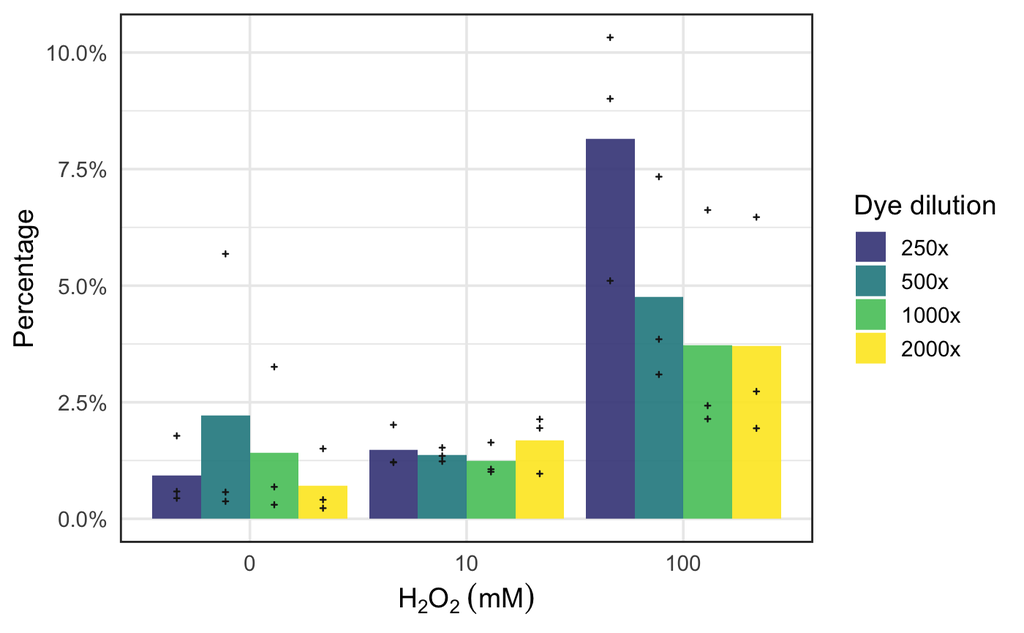

```r
p <- tmp |>
  # skip 1000 mM H2O2 because essentially all cells are PI-positive
  dplyr::filter(Dye == "PI", pop == "PI-positive", Treatment != "1000") |>
  ggplot(aes(x = Treatment, y = perc, group = Dilution)) +
  geom_bar(aes(fill = Dilution), stat = "summary", fun = "mean",
           position = pd, alpha = 0.9) +
  #stat_summary(fun.data = "mean_sdl", fun.args = list(mult = 1),
  #             position = pd,
  #             geom = "errorbar", width = 0.2, color = "black") +
  geom_point(position = pd, color = "gray10", size = .5, shape = 3) +
  scale_fill_viridis_d(name = "Dye dilution", option = "D", begin = 0.2) +
  scale_y_continuous(name = "Percentage", labels = scales::percent) +
  xlab(bquote(H[2]*O[2]~(mM))) +
  theme(strip.text = element_text(size = 14))

p
```

> - even at the lowest dilution (250x), there is minimal PI-positive population in the mock-treated sample, suggesting that over-staining is not a concern for PI at the tested dilutions.
> - the 100 mM H2O2 treated group shows the biggest differences among the dilutions, with the 250x dilution staining a noticeably higher fraction of cells as PI-positive. Whether this is due to over-staining or better staining of the damaged cells in this group is not clear, and the absolute level is still low compared to the 1M H2O2 treated group, which is not shown here because all four dilutions give essentially 100% PI-positive cells.

```r
ggsave(here("output", "20260612-PI-Dilutions-Gated-Percentage-Plot.png"),
       plot = p + theme(
         legend.title = element_text(size = rel(0.6)),
         legend.text = element_text(size = rel(0.6))
       ), width = 5, height = 3)
```

Inspect the flow density plots for PI-positive population across replicates for the 100 mM treated group

```r
# PI positive
select <- with(pData(gs),
               Treatment == "100" & Dye == "PI")
p1 <- ggcyto(gs[select], subset = "singlet",
            aes(x = BL1.H, y = BL3.H)) +
  geom_hex(bins = 128) +
  geom_gate(PI.gate) +
  geom_stats(digits = 1, adjust = c(1.5, 0.3)) +
  # reorder the facets to make the dilutions in the same order as the bar plot
  facet_grid(Date~factor(Dilution, levels = c("250", "500", "1000", "2000"),
                         labels = c("250x", "500x", "1000x", "2000x"))) +
  p.common +
  scPars
p1
```

[output not shown]

> - in all three days of experiments, the 250x dilution all gives the higher %PI+, but there is a lot of day-to-day variations.
> - in the 11/21 experiment, the %PI+ for the non-250x dilution are higher than the other two days.
> - overall, the impact of PI dilution in the range tested is much less compared with SYTO 9.

Below are Hanxi’s analysis code. They are commented out and saved as an archive for future reference.

```r
sub <- dat.f1[pData(dat.f1)$Dye == "PI" & pData(dat.f1)$Date == "112023"]
sg <- Subset(sub, singlet.gate)
p2 <- sg %>%
  ggcyto(aes(x = "BL1.H", y = "BL3.H")) +
  geom_hex(bins = 80, aes(fill = ..ncount..)) + geom_gate(dead.gate) + geom_stats(adjust = c(19, 0.1)) +
  facet_grid(Dilution ~ Treatment,
             labeller = as_labeller(c("0 mM" = "0 mM", "10 mM" = "10 mM", "100 mM" = "100 mM", "1000 mM" = "1000 mM",
                                      "250 x" = "250x", "500 x" = "500x", "1000 x" = "1000x", "2000 x" = "2000x"))) +
  theme_minimal()
p2 + scale_x_logicle(breaks = c(100, 1000, 10000)) + scale_y_logicle(breaks = c(100, 1000, 10000)) +
  xlab("FungaLight Green Fluorescence") + ylab("FungaLight Red Fluorescence")  +
  panel_border(color = "black", size = 2) +
  theme(axis.line = element_blank(),
        strip.background = element_blank(),
        axis.text.x = element_text(size = 25, face = "bold", color = "black"),  # Adjust size and face (bold)
        axis.text.y = element_text(size = 25, face = "bold", color = "black"),
        axis.title.x = element_text(size = 25, face = "bold"),
        axis.title.y = element_text(size = 20, face = "bold")
        )+
  theme(strip.text = element_text(size = 20, face = "bold"))
#ggsave("/space/htang5/Documents/FUN1_data_analysis/biol-4386-course-project-htang5/Methods Paper Writing/01-SYTO9-Midlog-Characterization/output/20240425-PI-Dilutions-Raw-Flow-Plot.png")
```

```r
sub <- dat.f1[pData(dat.f1)$Dye == "PI" & pData(dat.f1)$Date == "112023" & pData(dat.f1)$Dilution == "1000 x"]
sg <- Subset(sub, singlet.gate)
scPars <- ggcyto_par_set(limits = list(x = c(0,1e6), y = c(0,1e6)))
p2 <- sg %>%
  ggcyto(aes(x = "BL1.H", y = "BL3.H")) +
  geom_hex(bins = 80, aes(fill = ..ncount..)) + geom_gate(dead.gate, size = 1) + geom_stats(adjust = c(20, 0.1), size = 10) +
  facet_grid(Dilution ~ Treatment,
             labeller = as_labeller(c("0 mM" = "0 mM", "10 mM" = "10 mM", "100 mM" = "100 mM", "1000 mM" = "1000 mM",
                                      "250 x" = "250x", "500 x" = "500x", "1000 x" = "1000x", "2000 x" = "2000x"))) +
  theme_minimal()
p2 + scale_x_logicle (breaks = c(100, 1000, 10000, 100000, 1000000)) + scale_y_logicle (breaks = c(100, 1000, 10000, 100000, 1000000)) +
  coord_cartesian(xlim = c(1, 1e6), ylim = c(1, 1e6)) +
  xlab("FungaLight Green Fluorescence") + ylab("FungaLight Red Fluorescence")  +
  panel_border(color = "black", size = 2) +
  theme(axis.line = element_blank(),
        strip.background = element_blank(),
        axis.text.x = element_text(size = 25, face = "bold", color = "black"),  # Adjust size and face (bold)
        axis.text.y = element_text(size = 25, face = "bold", color = "black"),
        axis.title.x = element_text(size = 25, face = "bold"),
        axis.title.y = element_text(size = 20, face = "bold")
        )+
  theme(strip.text = element_text(size = 20, face = "bold"))
ggsave("/space/htang5/Documents/FUN1_data_analysis/biol-4386-course-project-htang5/Methods Paper Writing/01-SYTO9-Midlog-Characterization/output/20240521-PI-1000x-Raw-Flow-Plot.png")
```

```r
sub <- dat.f1[pData(dat.f1)$Dye == "SYTO9" & pData(dat.f1)$Date == "112023" & pData(dat.f1)$Dilution == "1000 x"]
sg <- Subset(sub, singlet.gate)
scPars <- ggcyto_par_set(limits = list(x = c(0,1e6), y = c(0,1e6)))
p2 <- sg %>%
  ggcyto(aes(x = "BL1.H", y = "BL3.H")) +
  geom_hex(bins = 80, aes(fill = ..ncount..)) + geom_gate(RP.gate, size = 1) + geom_stats(adjust = c(0.05, 0.1), size = 10) +
  facet_grid(Dilution ~ Treatment,
             labeller = as_labeller(c("0 mM" = "0 mM", "10 mM" = "10 mM", "100 mM" = "100 mM", "1000 mM" = "1000 mM",
                                      "250 x" = "250x", "500 x" = "500x", "1000 x" = "1000x", "2000 x" = "2000x"))) +
  theme_minimal()
p2 + scale_x_logicle (breaks = c(100, 1000, 10000, 100000, 1000000)) + scale_y_logicle (breaks = c(100, 1000, 10000, 100000, 1000000)) +
  coord_cartesian(xlim = c(1, 1e6), ylim = c(1, 1e6)) +
  xlab("FungaLight Green Fluorescence") + ylab("FungaLight Red Fluorescence")  +
  panel_border(color = "black", size = 2) +
  theme(axis.line = element_blank(),
        strip.background = element_blank(),
        axis.text.x = element_text(size = 25, face = "bold", color = "black"),  # Adjust size and face (bold)
        axis.text.y = element_text(size = 25, face = "bold", color = "black"),
        axis.title.x = element_text(size = 25, face = "bold"),
        axis.title.y = element_text(size = 20, face = "bold")
        )+
  theme(strip.text = element_text(size = 20, face = "bold"))
ggsave("/space/htang5/Documents/FUN1_data_analysis/biol-4386-course-project-htang5/Methods Paper Writing/01-SYTO9-Midlog-Characterization/output/20240521-SYTO9-1000x-Raw-Flow-Plot.png")
```

> PI quantifications

```r
gated_data %>%
   dplyr::filter(Dye == "PI") %>%
 mutate(Dilution = gsub("(\\d+) x", "\\1x", Dilution)) %>%
  mutate(Dilution = factor(Dilution, levels = c("250x", "500x", "1000x", "2000x"))) %>%
ggplot(aes(x = Dilution, y = percent_Dead)) +
  geom_point(size = 3, position = position_jitter(0.1)) +
  scale_color_brewer(palette = "Dark2") +
  stat_summary(fun.data = "mean_cl_boot", geom = "pointrange", color = "red2",
               size = 0.8, position = position_nudge(x = 0.3)) +
  facet_wrap(~ Treatment, nrow = 1, scales = "free_x") +
  scale_y_continuous(labels = scales::percent) +
  xlab("PI Folds Dilution") + ylab("% Red Positive Gated")  +
    theme_minimal() +
  theme(strip.text = element_text(size = rel(1), face = 3))+
  panel_border(color = "black", size = 1.5) +
  theme(axis.line = element_blank(),
        strip.background = element_blank(),
        axis.text.x = element_text(size = 20, face = "bold", color = "black", angle = 90),  # Adjust size and face (bold)
        axis.text.y = element_text(size = 20, face = "bold", color = "black"),
        axis.title.x = element_text(size = 20, face = "bold"),
        axis.title.y = element_text(size = 20, face = "bold")
        )+ theme(strip.text = element_text(size = 18, face = "bold"))
ggsave("/space/htang5/Documents/FUN1_data_analysis/biol-4386-course-project-htang5/Methods Paper Writing/01-SYTO9-Midlog-Characterization/output/20240409-PI-Dilutions-Gated-Percentage-Plot.png", width = 10, height = 7)
```

```r
sub <- dat.f1[pData(dat.f1)$Dye == "SYTO9" & pData(dat.f1)$Date == "112023"]
sg <- Subset(sub, singlet.gate)
p2 <- sg %>%
  ggcyto(aes(x = "BL1.H", y = "BL3.H")) +
  geom_hex(bins = 80, aes(fill = ..ncount..)) + geom_gate(RP1.gate) + geom_stats(adjust = c(0.01, 0.1)) +
  facet_grid(Dilution ~ Treatment,
             labeller = as_labeller(c("0 mM" = "0 mM", "10 mM" = "10 mM", "100 mM" = "100 mM", "1000 mM" = "1000 mM",
                                      "250 x" = "250x", "500 x" = "500x", "1000 x" = "1000x", "2000 x" = "2000x"))) +
  theme_minimal()
p2 + scale_x_logicle() + scale_y_logicle() +
  coord_cartesian(xlim = c(1, 1e6), ylim = c(1, 1e6)) +
  xlab("FungaLight Green Fluorescence") + ylab("FungaLight Red Fluorescence") +
  panel_border(color = "black", size = 1) +
  theme(axis.line = element_blank(),
        strip.background = element_blank(),
        axis.text.x = element_text(size = 10, color = "black"),  # Adjust size and face (bold)
        axis.text.y = element_text(size = 10, color = "black"),
        axis.title.x = element_text(size = 16, face = "bold"),
        axis.title.y = element_text(size = 16, face = "bold")
        ) +
  theme(strip.text = element_text(size = 12, face = "bold"))
ggsave("/space/htang5/Documents/FUN1_data_analysis/biol-4386-course-project-htang5/Methods Paper Writing/01-SYTO9-Midlog-Characterization/output/20240409-SYTO9-Dilutions-Raw-Flow-Plot.png", width = 7, height = 5)
```

# Extract MFI across flowFrames

> MFI are extracted and wrote into tsv. The tsv is stored in the input folder.

```r
tmp <- fsApply(dat.f1, each_col, median)
if(all(rownames(tmp) == rownames(sample))){
  combined_data_f1 <- cbind(pData(dat.f1), tmp) %>%
    as.tibble() %>% relocate(name, .after = last_col())
}
#write_tsv(combined_data_f1, file = "../Input/20231228-fig-1-MFI-ht.tsv")
print(combined_data_f1)
```

# Graph Green MFIs against teatment and group by dye concentration

> Several output graphs are produced. The graphs are include in Figure 1 Panel A.

```r
combined_data_f1 %>%
  dplyr::filter(Treatment == "0 mM") %>%
   mutate(Label = paste(Dilution, Dye, sep = "_"),
         Signal = ifelse(Dye == "PI", BL3.H, BL1.H)) %>%
  mutate(Dilution = gsub("(\\d+) x", "\\1x", Dilution)) %>%
  mutate(Dilution = factor(Dilution, levels = c("250x", "500x", "1000x", "2000x"))) %>%
  ggplot(aes(x = Dilution, y = Signal, group = Dye, color = Dye))  +
  geom_bar(aes(fill = Dye), stat = "summary", fun = "mean", position = position_dodge(), alpha = 0.7) +
  theme_minimal()  +
  xlab("Dye Folds Dilution") + ylab("Fluorescent Signal")  +
    theme_minimal() +
  panel_border(color = "black", size = 1.5) +
   theme(axis.line = element_blank(),
        strip.background = element_blank(),
        axis.text.x = element_text(size = 20, face = "bold", color = "black"),  # Adjust size and face (bold)
        axis.text.y = element_text(size = 20, face = "bold", color = "black"),
        axis.title.x = element_text(size = 20, face = "bold"),
        axis.title.y = element_text(size = 20, face = "bold"),
        legend.title = element_text(size = 18, face = "bold"),
        legend.text = element_text(size = 18, face = "bold"),  # Set legend text size and face
        strip.text = element_text(size = 18, face = "bold")  # Adjust size and face for strip text
  )
ggsave("/space/htang5/Documents/FUN1_data_analysis/biol-4386-course-project-htang5/Methods Paper Writing/01-SYTO9-Midlog-Characterization/output/20240411-SYTO9-vsPI-Plot.png")
```

```r
pf1a <- combined_data_f1 %>%
  dplyr::filter(Dye == "SYTO9") %>%
  dplyr::filter(Dilution == "1000 x") %>%
  mutate(Treatment = gsub("1000 mM", "1 M", Treatment)) %>%
  mutate(Treatment = factor(Treatment, levels = c("0 mM", "10 mM", "100 mM", "1 M"))) %>%
  ggplot(aes(x = Treatment, y = BL1.H)) +
  geom_point(stroke = 1, size = 2, position = position_jitter(0.2)) +
  stat_summary(fun.data = "mean_cl_boot", geom = "pointrange", color = "red2",
               size = 0.8, position = position_nudge(x = 0.1)) +
  theme_minimal()
pf1a + labs(x = bquote(H[2]*O[2]), y = "Green MFI") +
  panel_border(color = "black", size = 1.5) +
  theme(axis.line = element_blank(),
        strip.background = element_blank(),
        axis.text.x = element_text(size = 25, face = "bold", color = "black"),  # Adjust size and face (bold)
        axis.text.y = element_text(size = 25, face = "bold", color = "black"),
        axis.title.x = element_text(size = 25, face = "bold"),
        axis.title.y = element_text(size = 25, face = "bold")
        )
ggsave("../output/20240522-SYTO9-Dilutions-Green-MFI-Plot.png", width = 7, height = 5)
```

> Graph red MFI for various SYTO9 dilutions

```r
pf1a <- combined_data_f1 %>%
  dplyr::filter(Dye == "SYTO9") %>%
  dplyr::filter(Dilution == "1000 x") %>%
  mutate(Treatment = gsub("1000 mM", "1 M", Treatment)) %>%
  mutate(Treatment = factor(Treatment, levels = c("0 mM", "10 mM", "100 mM", "1 M"))) %>%
  ggplot(aes(x = Treatment, y = BL3.H)) +
  geom_point(stroke = 1, size = 2, position = position_jitter(0.2)) +
  stat_summary(fun.data = "mean_cl_boot", geom = "pointrange", color = "red2",
               size = 0.8, position = position_nudge(x = 0.1)) +
  theme_minimal()
pf1a +
 labs(x = bquote(H[2]*O[2]), y = "Red MFI") +
  panel_border(color = "black", size = 1.5) +
  theme(axis.line = element_blank(),
        strip.background = element_blank(),
        axis.text.x = element_text(size = 25, face = "bold", color = "black"),  # Adjust size and face (bold)
        axis.text.y = element_text(size = 25, face = "bold", color = "black"),
        axis.title.x = element_text(size = 25, face = "bold"),
        axis.title.y = element_text(size = 25, face = "bold")
        )
ggsave("../output/20240522-SYTO9-Dilutions-Red-MFI-Plot.png", width = 7, height = 5)
```

> Graph a scatter plot for median red and greens for each population No output from this plotting.

```r
combined_data_f1 %>%
  dplyr::filter(Dye == "SYTO9") %>%
  dplyr::filter(Treatment == "0 mM") %>%
  ggplot(aes(x = BL1.H, y = BL3.H)) +
  geom_point(aes(color = interaction(Dye, Dilution))) +
  facet_wrap(~Treatment)
  #stat_summary(fun.data = "mean_cl_boot", geom = "line", size = 0.2, position = position_nudge(x = 0.1), aes(group = interaction(Dye, Dilution), color = interaction(Dye, Dilution))) +
  labs(x = "Hydrogen Peroxide Treatment", y = "Median Red Fluorescence") +
  panel_border(color = "black", size = 1.5) +
  theme(axis.line = element_blank(),
        #axis.title.x = element_blank(),
        strip.background = element_blank(),
        axis.text.x = element_text(size = 16, face = "bold"),  # Adjust size and face (bold)
        axis.text.y = element_text(size = 16, face = "bold"),
        axis.title.x = element_text(size = 16, face = "bold"),
        axis.title.y = element_text(size = 16, face = "bold")
        )
```

```r
p1 <- gated_data %>%
  dplyr::filter(Dye == "SYTO9") %>%
  dplyr::filter(Dilution == "1000 x") %>%
   dplyr::filter(!(Treatment %in% c("0 mM")))  %>%
  mutate(Treatment = gsub(" mM", "", Treatment)) %>%
  ggplot(aes(x = Treatment, y = percent_Live))  +
  geom_bar(stat = "summary", fun = "mean", fill = "skyblue2", alpha = 0.7) +
  geom_point(size = 3, position = position_jitter(0.2)) +
   scale_y_continuous(labels = scales::percent_format()) +
  labs(x = bquote(H[2]*O[2]~(mM)), y = "% Live Population") +
  ggtitle("SYTO9 only") +
  theme(plot.title = element_text(hjust = 30)) +
  theme_cowplot(font_size = 16)

p2 <- gated_data %>%
  dplyr::filter(Dye == "SYTO9") %>%
  dplyr::filter(Dilution == "1000 x") %>%
   dplyr::filter(!(Treatment %in% c("0 mM")))  %>%
  ggplot(aes(x = Treatment, y = percent_Live))  +
  geom_bar(stat = "summary", fun = "mean", fill = "skyblue2", alpha = 0.7) +
  geom_point(size = 3, position = position_jitter(0.2)) +
   scale_y_continuous(labels = scales::percent_format()) +
  labs(x = bquote(H[2]*O[2]~(mM)), y = "% Red Negative") +
  ggtitle("SYTO9 only") +
  theme(plot.title = element_text(hjust = 30)) +
  theme_cowplot(font_size = 16)

p3 <- gated_data %>%
  dplyr::filter(Dye == "SYTO9") %>%
  dplyr::filter(Dilution == "1000 x") %>%
   dplyr::filter(!(Treatment %in% c("0 mM")))  %>%
  ggplot(aes(x = Treatment, y = percent_Live))  +
  geom_bar(stat = "summary", fun = "mean", fill = "skyblue2", alpha = 0.7) +
  geom_point(size = 3, position = position_jitter(0.2)) +
   scale_y_continuous(labels = scales::percent_format()) +
  labs(x = bquote(H[2]*O[2]~(mM)), y = "% Red Negative") +
  ggtitle("SYTO9 only") +
  theme(plot.title = element_text(hjust = 30)) +
  theme_cowplot(font_size = 16)

combined_plot <- plot_grid(p1, p2, p3, nrow = 1, ncol = 3, common.legend = TRUE, align = 'hv', widths = c(6, 6, 6))
print(combined_plot)
ggsave("../output/20240430-SYTO9-Cg-Log-Gated.png")
```

—>